# Final Flanker RT Analyses

PD Inhibition Project

Michael Hallquist

28 May 2020

This file contains final MLMs for reaction times on the flanker task for the PD Inhibition DDM project.

Note: I have adopted the common convention of only analyzing RTs for correct responses. This assumes that whatever process gives rise to the RT for an incorrect response is not commensurable. The alternative would be to allow for `correct` to enter into the model as a predict of the current trial’s RT. This could support moderation analyses – for example, whether error RTs are faster in the mostly congruent condition for incongruent trials. The downside is all of the ensuing multi-way interactions, many of which are not of central interest.

N.B. For the AIC comparisons to be valid, we need to use method=‘ML’ throughout. Once we have a winning model, or one where the parameters matter, re-estimate with REML. `update(mm, method='REML')`

To reduce the number of models, I don’t consider block diagonal matrices for L2 random effects. This is achieved with `pdDiag()` and basically estimates a unique variance component for each level of a factor. But the fits of these models are extremely close to the more conventional block within id `id/block` parameterization for random effects. Given that the latter is much more conventional, let’s stick with that when we want to check for heterogeneity in L2 by condition.

# LME approach

These models permit heterogeneous L1 residual variability

## m1: design effects, random intercept of subject

```r
minfo[["m1"]] <- c(fixed="Congruency, Block", l1="Homogeneous", l2="Subject: Intercept")
m1 <- lme(rt_inv ~ cond*block,
          random = ~ 1 | id,
          na.action = na.exclude,
          data = flanker, method='ML')

m1_reml <- update(m1, method='REML')
```

```r
flextable(car::Anova(m1, type=3)) %>% autofit()
```

| Chisq | Df | Pr(>Chisq) |
| --- | --- | --- |
| 8196.32 | 1 | 0.00e+00 |
| 162.18 | 1 | 3.78e-37 |
| 7.38 | 1 | 6.58e-03 |
| 14.82 | 1 | 1.18e-04 |

```r
#Get model-predicted means in original RT scale. Force back onto original RT using custom function
rg <- update(ref_grid(m1_reml), tran=list(linkinv=function(x) { -1000/x }, mu.eta=function(x) { -1000/x }), predict.type="response")
res_trans <- emmeans(rg, ~cond|block)

flextable(as.data.frame(res_trans)) %>% colformat_num(j=c("response", "SE", "lower.CL", "upper.CL"), digits=2) %>% autofit()
```

| cond | block | response | SE | df | lower.CL | upper.CL |
| --- | --- | --- | --- | --- | --- | --- |
| congruent | most_incon | 370.13 | 11.09 | 106 | 362.17 | 378.46 |
| incongruent | most_incon | 386.56 | 11.38 | 106 | 378.02 | 395.48 |
| congruent | most_con | 373.50 | 11.00 | 106 | 365.54 | 381.83 |
| incongruent | most_con | 397.91 | 11.95 | 106 | 388.70 | 407.56 |

## m2: design effects, allow for L2 random intercept to vary by block

Use nested RE specification.

```r
minfo[["m2"]] <- c(fixed="Congruency, Block", l1="Homogeneous", l2="Block Within Subject: Intercept")
m2 <- lme(rt_inv ~ cond*block,
          random=~1|id/block,
          na.action = na.exclude,
          data = flanker, method='ML')
```

```r
flextb_vif(m2)
```

| Predictor | vif |
| --- | --- |
| cond | 2.08 |
| block | 1.39 |
| cond:block | 2.09 |

```r
flextable(car::Anova(m2, type=3)) %>% autofit()
```

| Chisq | Df | Pr(>Chisq) |
| --- | --- | --- |
| 7997.73 | 1 | 0.00e+00 |
| 166.21 | 1 | 4.98e-38 |
| 3.62 | 1 | 5.71e-02 |
| 14.51 | 1 | 1.39e-04 |

## m3: design effects, allow for L1 residual variance to vary by block

```r
minfo[["m3"]] <- c(fixed="Congruency, Block", l1="Per Block", l2="Block within subject: Intercept")
m3 <- lme(rt_inv ~ cond*block,
          random=~1|id/block,
          weights=varIdent(form=~1|block),
          na.action = na.exclude,
          data = flanker, method='ML')
summary(m3)
```

```
## Linear mixed-effects model fit by maximum likelihood
##  Data: flanker
##     AIC   BIC logLik
##   14536 14597  -7260
##
## Random effects:
##  Formula: ~1 | id
##         (Intercept)
## StdDev:       0.295
##
##  Formula: ~1 | block %in% id
##         (Intercept) Residual
## StdDev:      0.0666    0.358
##
## Variance function:
##  Structure: Different standard deviations per stratum
##  Formula: ~1 | block
##  Parameter estimates:
## most_incon   most_con
##       1.00       1.07
## Fixed effects: rt_inv ~ cond * block
##                                Value Std.Error    DF t-value p-value
## (Intercept)                   -2.702   0.03015 16039   -89.6  0.0000
## condincongruent                0.115   0.00864 16039    13.4  0.0000
## blockmost_con                  0.024   0.01265   106     1.9  0.0581
## condincongruent:blockmost_con  0.049   0.01275 16039     3.8  0.0001
##  Correlation:
##                               (Intr) cndncn blckm_
## condincongruent               -0.198
## blockmost_con                 -0.244  0.471
## condincongruent:blockmost_con  0.134 -0.677 -0.478
##
## Standardized Within-Group Residuals:
##     Min      Q1     Med      Q3     Max
## -4.4977 -0.5985  0.0157  0.5960  4.1934
##
## Number of Observations: 16255
## Number of Groups:
##            id block %in% id
##           107           214
```

```r
#stargazer(m3, type="html")
flextable(car::Anova(m3, type=3)) %>% autofit()
```

| Chisq | Df | Pr(>Chisq) |
| --- | --- | --- |
| 8031.10 | 1 | 0.00e+00 |
| 178.53 | 1 | 1.01e-40 |
| 3.67 | 1 | 5.54e-02 |
| 14.49 | 1 | 1.41e-04 |

```r
flextable(render_aictab(minfo=minfo, m1, m2, m3)) %>% autofit()
```

| model | fixed | l1 | l2 | logLik | AIC | dAIC | df | weight |
| --- | --- | --- | --- | --- | --- | --- | --- | --- |
| m1 | Congruency, Block | Homogeneous | Subject: Intercept | -7343 | 14698 | 162.6 | 6 | 4.98e-36 |
| m2 | Congruency, Block | Homogeneous | Block Within Subject: Intercept | -7279 | 14571 | 35.9 | 7 | 1.59e-08 |
| m3 | Congruency, Block | Per Block | Block within subject: Intercept | -7260 | 14536 | 0.0 | 8 | 1.00e+00 |

## m4: Allow L1 residual variability to depend on both condition and block

```r
minfo[["m4"]] <- c(fixed="Congruency, Block", l1="Per Block and Condition", l2="Block within subject: Intercept")
m4 <- lme(rt_inv ~ cond*block,
          random=~1|id/block,
          weights=varIdent(form=~1|block*cond),
          na.action = na.exclude,
          data = flanker, method='ML')
summary(m4)
```

```
## Linear mixed-effects model fit by maximum likelihood
##  Data: flanker
##     AIC   BIC logLik
##   14530 14607  -7255
##
## Random effects:
##  Formula: ~1 | id
##         (Intercept)
## StdDev:       0.296
##
##  Formula: ~1 | block %in% id
##         (Intercept) Residual
## StdDev:      0.0667    0.361
##
## Variance function:
##  Structure: Different standard deviations per stratum
##  Formula: ~1 | block * cond
##  Parameter estimates:
## most_incon*incongruent   most_incon*congruent     most_con*congruent   most_con*incongruent
##                  1.000                  0.982                  1.049                  1.104
## Fixed effects: rt_inv ~ cond * block
##                                Value Std.Error    DF t-value p-value
## (Intercept)                   -2.702   0.03014 16039   -89.6  0.0000
## condincongruent                0.115   0.00858 16039    13.5  0.0000
## blockmost_con                  0.024   0.01258   106     1.9  0.0569
## condincongruent:blockmost_con  0.048   0.01286 16039     3.8  0.0002
##  Correlation:
##                               (Intr) cndncn blckm_
## condincongruent               -0.194
## blockmost_con                 -0.242  0.465
## condincongruent:blockmost_con  0.130 -0.667 -0.464
##
## Standardized Within-Group Residuals:
##     Min      Q1     Med      Q3     Max
## -4.4718 -0.6017  0.0136  0.5967  4.1736
##
## Number of Observations: 16255
## Number of Groups:
##            id block %in% id
##           107           214
```

```r
flextable(render_aictab(minfo=minfo, m1, m2, m3, m4)) %>% autofit()
```

| model | fixed | l1 | l2 | logLik | AIC | dAIC | df | weight |
| --- | --- | --- | --- | --- | --- | --- | --- | --- |
| m1 | Congruency, Block | Homogeneous | Subject: Intercept | -7343 | 14698 | 168.26 | 6 | 2.74e-37 |
| m2 | Congruency, Block | Homogeneous | Block Within Subject: Intercept | -7279 | 14571 | 41.59 | 7 | 8.78e-10 |
| m3 | Congruency, Block | Per Block | Block within subject: Intercept | -7260 | 14536 | 5.68 | 8 | 5.51e-02 |
| m4 | Congruency, Block | Per Block and Condition | Block within subject: Intercept | -7255 | 14530 | 0.00 | 10 | 9.45e-01 |

Interim conclusions about random effects structure:

1. Allow for per-block random intercept (nested random effect)
2. Allow for L1 residual variance to vary by block and trial condition

But!! Obtaining p-values and denominator degrees of freedom is a somewhat tortured process because neither Satterthwaite nor Kenward-Roger corrections for degrees of freedom are provided. Moreover, we don’t have any conceptual interest in L1 heterogeneity. Likewise, when we switch to `glmer` for accuracy, we no longer have the option for heterogeneous L1 variances since `nlme` doesn’t provide a binary logistic model as far as I know.

# LMER-based modeling

## m1: design effects, random intercept of subject

```r
minfo <- list() #re-initialize now that we're eliminating l1 heterogeneity
```

```r
minfo[["m1"]] <- c(fixed="Congruency, Block", l2="Subject: Intercept")
m1 <- lmer(rt_inv ~ cond*block + (1|id),
          na.action = na.exclude,
          data = flanker, REML=FALSE)
m1_reml <- update(m1, REML=TRUE)
```

```r
flextable(anova(m1) %>% rownames_to_column("Effect")) %>% autofit() #lmerTest reports Satterthwaite degrees of freedom
```

| Effect | Sum Sq | Mean Sq | NumDF | DenDF | F value | Pr(>F) |
| --- | --- | --- | --- | --- | --- | --- |
| cond | 66.10 | 66.10 | 1 | 16149 | 471.4 | 4.70e-103 |
| block | 8.21 | 8.21 | 1 | 16148 | 58.5 | 2.12e-14 |
| cond:block | 2.08 | 2.08 | 1 | 16148 | 14.8 | 1.19e-04 |

```r
#flextable(car::Anova(m1, type=3)) %>% autofit()

#Get model-predicted means in original RT scale. Force back onto original RT using custom function
rg <- update(ref_grid(m1_reml), tran=list(linkinv=function(x) { -1000/x }, mu.eta=function(x) { -1000/x }), predict.type="response")
res_trans <- emmeans(rg, ~cond|block, lmer.df = "satterthwaite")

# emmeans(m1_reml, ~cond|block, lmer.df = "satterthwaite") #in inverse units

flextable(as.data.frame(res_trans)) %>%
  colformat_num(j=c("response", "SE", "lower.CL", "upper.CL"), digits=2) %>%
  autofit()
```

| cond | block | response | SE | df | lower.CL | upper.CL |
| --- | --- | --- | --- | --- | --- | --- |
| congruent | most_incon | 370.13 | 11.09 | 118 | 362.18 | 378.45 |
| incongruent | most_incon | 386.56 | 11.38 | 110 | 378.03 | 395.48 |
| congruent | most_con | 373.50 | 11.00 | 110 | 365.54 | 381.82 |
| incongruent | most_con | 397.91 | 11.95 | 119 | 388.71 | 407.55 |

## m2: design effects, allow for L2 random intercept to vary by block

Use nested RE specification.

```r
minfo[["m2"]] <- c(fixed="Congruency, Block", l2="Block within subject: Intercept")
m2 <- lmer(rt_inv ~ cond*block + (1|id/block),
          na.action = na.exclude,
          data = flanker, REML=FALSE)
m2_reml <- update(m2, REML=TRUE)
```

```r
flextable(anova(m2) %>% rownames_to_column("Effect")) %>% autofit()
```

| Effect | Sum Sq | Mean Sq | NumDF | DenDF | F value | Pr(>F) |
| --- | --- | --- | --- | --- | --- | --- |
| cond | 66.21 | 66.21 | 1 | 16052 | 479.9 | 7.75e-105 |
| block | 2.63 | 2.63 | 1 | 120 | 19.0 | 2.73e-05 |
| cond:block | 2.00 | 2.00 | 1 | 16073 | 14.5 | 1.40e-04 |

```r
#car::Anova(m2, type=3)
flextable(render_aictab(minfo=minfo, m1, m2)) %>% autofit()
```

| model | fixed | l2 | logLik | AIC | dAIC | df | weight |
| --- | --- | --- | --- | --- | --- | --- | --- |
| m1 | Congruency, Block | Subject: Intercept | -7343 | 14698 | 127 | 6 | 3.12e-28 |
| m2 | Congruency, Block | Block within subject: Intercept | -7279 | 14571 | 0 | 7 | 1.00e+00 |

```r
rg <- update(ref_grid(m2_reml),
             tran=list(linkinv=function(x) { -1000/x }, mu.eta=function(x) { -1000/x }),
             predict.type="response")

res_trans <- emmeans(rg, ~cond|block, lmer.df = "satterthwaite")
pairs(res_trans)
```

```
## Note: Use 'contrast(regrid(object), ...)' to obtain contrasts of back-transformed estimates
```

```
## block = most_incon:
##  contrast                estimate      SE    df t.ratio p.value
##  congruent - incongruent   -0.115 0.00895 16069 -12.890 <.0001
##
## block = most_con:
##  contrast                estimate      SE    df t.ratio p.value
##  congruent - incongruent   -0.164 0.00908 16052 -18.060 <.0001
##
## Note: contrasts are still on the custom scale
## Degrees-of-freedom method: satterthwaite
```

```r
# emmeans(m1_reml, ~cond|block, lmer.df = "satterthwaite") #in inverse units

flextable(as.data.frame(res_trans)) %>%
  colformat_num(j=c("response", "SE", "lower.CL", "upper.CL"), digits=2) %>%
  autofit()
```

| cond | block | response | SE | df | lower.CL | upper.CL |
| --- | --- | --- | --- | --- | --- | --- |
| congruent | most_incon | 370.13 | 11.23 | 123 | 362.08 | 378.55 |
| incongruent | most_incon | 386.64 | 11.54 | 115 | 378.00 | 395.68 |
| congruent | most_con | 373.48 | 11.14 | 115 | 365.42 | 381.91 |
| incongruent | most_con | 397.84 | 12.09 | 124 | 388.54 | 407.59 |

```r
pairs(emmeans(m2_reml, ~cond|block))
```

```
## block = most_incon:
##  contrast                estimate      SE    df t.ratio p.value
##  congruent - incongruent   -0.115 0.00895 16069 -12.890 <.0001
##
## block = most_con:
##  contrast                estimate      SE    df t.ratio p.value
##  congruent - incongruent   -0.164 0.00908 16052 -18.060 <.0001
##
## Degrees-of-freedom method: satterthwaite
```

```r
pairs(emmeans(m2_reml, ~ cond * block), simple="each")
```

```
## $`simple contrasts for cond`
## block = most_incon:
##  contrast                estimate      SE    df t.ratio p.value
##  congruent - incongruent   -0.115 0.00895 16069 -12.890 <.0001
##
## block = most_con:
##  contrast                estimate      SE    df t.ratio p.value
##  congruent - incongruent   -0.164 0.00908 16052 -18.060 <.0001
##
## Degrees-of-freedom method: satterthwaite
##
## $`simple contrasts for block`
## cond = congruent:
##  contrast              estimate     SE  df t.ratio p.value
##  most_incon - most_con  -0.0242 0.0128 204 -1.900  0.0594
##
## cond = incongruent:
##  contrast              estimate     SE  df t.ratio p.value
##  most_incon - most_con  -0.0728 0.0129 213 -5.630  <.0001
##
## Degrees-of-freedom method: satterthwaite
```

```r
pairs(pairs(emmeans(m2_reml, ~cond|block)), by=NULL) #difference of differences
```

```
##  contrast                                                              estimate     SE    df t.ratio p.value
##  congruent - incongruent,most_incon - congruent - incongruent,most_con   0.0485 0.0127 16071 3.810   0.0001
##
## Degrees-of-freedom method: satterthwaite
```

## m3: Add trial_z as fixed

```r
minfo[["m3"]] <- c(fixed="Congruency, Block, Trial", l2="Block within subject: Intercept")
m3 <- lmer(rt_inv ~ cond*block + trial_z + (1|id/block),
          na.action = na.exclude,
          data = flanker, REML=FALSE)
```

## m4: Add trial_z as random, too, but only at subject level, not block-specific

```r
minfo[["m4"]] <- c(fixed="Congruency, Block, Trial", l2="Block within subject:Intercept\nSubject: Trial")
m4 <- lmer(rt_inv ~ cond*block + trial_z + (1 + trial_z | id) + (1 | id:block),
          na.action = na.exclude,
          data = flanker, REML=FALSE)
```

## m5: Add trial_z as random both per subject and block

```r
minfo[["m5"]] <- c(fixed="Congruency, Block, Trial", l2="Block within subject: Intercept, Trial")
m5 <- lmer(rt_inv ~ cond*block + trial_z + (1 + trial_z | id/block),
          na.action = na.exclude,
          data = flanker, REML=FALSE)
```

```r
summary(m5)
```

```
## Linear mixed model fit by maximum likelihood . t-tests use Satterthwaite's method ['lmerModLmerTest']
## Formula: rt_inv ~ cond * block + trial_z + (1 + trial_z | id/block)
##    Data: flanker
##
##      AIC      BIC   logLik deviance df.resid
##    13910    14003    -6943    13886    16243
##
## Scaled residuals:
##    Min     1Q Median     3Q    Max
## -4.490 -0.599  0.014  0.592  4.297
##
## Random effects:
##  Groups   Name        Variance Std.Dev. Corr
##  block:id (Intercept) 0.00462  0.0680
##           trial_z     0.00687  0.0829   0.16
##  id       (Intercept) 0.08809  0.2968
##           trial_z     0.00271  0.0520   -0.12
##  Residual             0.12951  0.3599
## Number of obs: 16255, groups:  block:id, 214; id, 107
##
## Fixed effects:
##                                  Estimate  Std. Error          df t value Pr(>|t|)
## (Intercept)                      -2.70173     0.03030   123.72588  -89.16  < 2e-16 ***
## condincongruent                   0.11571     0.00868 15870.60190   13.33  < 2e-16 ***
## blockmost_con                     0.02343     0.01263   200.01585    1.85   0.0651 .
## trial_z                          -0.02571     0.00848   102.10784   -3.03   0.0031 **
## condincongruent:blockmost_con     0.04934     0.01236 15854.09419    3.99 0.000066 ***
## ---
## Signif. codes:  0 '***' 0.001 '**' 0.01 '*' 0.05 '.' 0.1 ' ' 1
##
## Correlation of Fixed Effects:
##             (Intr) cndncn blckm_ tril_z
## condncngrnt -0.198
## blockmst_cn -0.247  0.474
## trial_z     -0.058 -0.001  0.022
## cndncngrn:_  0.139 -0.702 -0.477  0.000
```

```r
flextable(render_aictab(minfo=minfo, m1, m2, m3, m4, m5)) %>% autofit()
```

| model | fixed | l2 | logLik | AIC | dAIC | df | weight |
| --- | --- | --- | --- | --- | --- | --- | --- |
| m1 | Congruency, Block | Subject: Intercept | -7343 | 14698 | 787.8 | 6 | 8.38e-172 |
| m2 | Congruency, Block | Block within subject: Intercept | -7279 | 14571 | 661.2 | 7 | 2.68e-144 |
| m3 | Congruency, Block, Trial | Block within subject: Intercept | -7242 | 14500 | 589.9 | 8 | 8.11e-129 |
| m4 | Congruency, Block, Trial | Block within subject:Intercept Subject: Trial | -6991 | 14002 | 91.7 | 10 | 1.20e-20 |
| m5 | Congruency, Block, Trial | Block within subject: Intercept, Trial | -6943 | 13910 | 0.0 | 12 | 1.00e+00 |

## m6: Add trial x block interaction as fixed

```r
minfo[["m6"]] <- c(
  fixed="Congruency, Block, Congruency x Block, Trial, Block x Trial",
  l2="Block within subject: Intercept, Trial")
```

```r
m6 <- lmer(rt_inv ~ cond*block + trial_z*block + (1 + trial_z | id/block),
          na.action = na.exclude,
          data = flanker, REML=FALSE)
```

```r
flextable(render_aictab(minfo=minfo, m1, m2, m3, m4, m5, m6)) %>% autofit()
```

| model | fixed | l2 | logLik | AIC | dAIC | df | weight |
| --- | --- | --- | --- | --- | --- | --- | --- |
| m1 | Congruency, Block | Subject: Intercept | -7343 | 14698 | 787.84 | 6 | 6.09e-172 |
| m2 | Congruency, Block | Block within subject: Intercept | -7279 | 14571 | 661.17 | 7 | 1.95e-144 |
| m3 | Congruency, Block, Trial | Block within subject: Intercept | -7242 | 14500 | 589.88 | 8 | 5.89e-129 |
| m4 | Congruency, Block, Trial | Block within subject:Intercept Subject: Trial | -6991 | 14002 | 91.74 | 10 | 8.72e-21 |
| m5 | Congruency, Block, Trial | Block within subject: Intercept, Trial | -6943 | 13910 | 0.00 | 12 | 7.27e-01 |
| m6 | Congruency, Block, Congruency x Block, Trial, Block x Trial | Block within subject: Intercept, Trial | -6943 | 13912 | 1.96 | 13 | 2.73e-01 |

## m7: Trial within run (run_trial) as fixed

trial x block is not significant, drop from consideration

```r
minfo[["m7"]] <- c(
  fixed="Congruency, Block, Congruency x Block, Trial, Run Trial",
  l2="Block within subject: Intercept, Trial")
```

```r
m7 <- lmer(rt_inv ~ cond*block + trial_z + run_trial_z + (1 + trial_z | id/block),
          na.action = na.exclude,
          data = flanker, REML=FALSE)
```

```r
flextable(render_aictab(minfo=minfo, m1, m2, m3, m4, m5, m6, m7)) %>% autofit()
```

| model | fixed | l2 | logLik | AIC | dAIC | df | weight |
| --- | --- | --- | --- | --- | --- | --- | --- |
| m1 | Congruency, Block | Subject: Intercept | -7343 | 14698 | 811.9 | 6 | 4.89e-177 |
| m2 | Congruency, Block | Block within subject: Intercept | -7279 | 14571 | 685.3 | 7 | 1.57e-149 |
| m3 | Congruency, Block, Trial | Block within subject: Intercept | -7242 | 14500 | 614.0 | 8 | 4.73e-134 |
| m4 | Congruency, Block, Trial | Block within subject:Intercept Subject: Trial | -6991 | 14002 | 115.8 | 10 | 7.01e-26 |
| m5 | Congruency, Block, Trial | Block within subject: Intercept, Trial | -6943 | 13910 | 24.1 | 12 | 5.84e-06 |
| m6 | Congruency, Block, Congruency x Block, Trial, Block x Trial | Block within subject: Intercept, Trial | -6943 | 13912 | 26.1 | 13 | 2.20e-06 |
| m7 | Congruency, Block, Congruency x Block, Trial, Run Trial | Block within subject: Intercept, Trial | -6930 | 13886 | 0.0 | 13 | 1.00e+00 |

## m8: Add run trial as random at subject level only

```r
minfo[["m8"]] <- c(
  fixed="Congruency, Block, Trial, Run Trial",
  l2="Block within subject: Intercept, Trial\nSubject: Run Trial")
```

```r
m8 <- lmer(rt_inv ~ cond*block + trial_z + run_trial_z +
             (1 + trial_z + run_trial_z | id) +
             (1 + trial_z | id:block),
          na.action = na.exclude, control=lmerControl(optCtrl=list(maxfun=2e4)),
          data = flanker, REML=FALSE)
flextb_vif(m8)
```

| Predictor | vif |
| --- | --- |
| cond | 2.07 |
| block | 1.36 |
| trial_z | 1.12 |
| run_trial_z | 1.12 |
| cond:block | 2.08 |

```r
flextable(render_aictab(minfo=minfo, m1, m2, m3, m4, m5, m6, m7, m8)) %>% autofit()
```

| model | fixed | l2 | logLik | AIC | dAIC | df | weight |
| --- | --- | --- | --- | --- | --- | --- | --- |
| m1 | Congruency, Block | Subject: Intercept | -7343 | 14698 | 915 | 6 | 2.37e-199 |
| m2 | Congruency, Block | Block within subject: Intercept | -7279 | 14571 | 788 | 7 | 7.57e-172 |
| m3 | Congruency, Block, Trial | Block within subject: Intercept | -7242 | 14500 | 717 | 8 | 2.29e-156 |
| m4 | Congruency, Block, Trial | Block within subject:Intercept Subject: Trial | -6991 | 14002 | 219 | 10 | 3.39e-48 |
| m5 | Congruency, Block, Trial | Block within subject: Intercept, Trial | -6943 | 13910 | 127 | 12 | 2.82e-28 |
| m6 | Congruency, Block, Congruency x Block, Trial, Block x Trial | Block within subject: Intercept, Trial | -6943 | 13912 | 129 | 13 | 1.06e-28 |
| m7 | Congruency, Block, Congruency x Block, Trial, Run Trial | Block within subject: Intercept, Trial | -6930 | 13886 | 103 | 13 | 4.83e-23 |
| m8 | Congruency, Block, Trial, Run Trial | Block within subject: Intercept, Trial Subject: Run Trial | -6876 | 13783 | 0 | 16 | 1.00e+00 |

## m9: Add run trial as random at subject and block level

Indeed, we see a big boost allowing run_trial to be random at subject and block level

```r
minfo[["m9"]] <- c(
  fixed="Congruency, Block, Congruency x Block, Trial, Run Trial",
  l2="Block within subject:Intercept, Trial, Run Trial")
```

```r
m9 <- lmer(rt_inv ~ cond*block + trial_z + run_trial_z +
             (1 + trial_z + run_trial_z | id) +
             (1 + trial_z + run_trial_z | id:block),
          na.action = na.exclude,
          data = flanker, REML=FALSE)
```

```
## boundary (singular) fit: see ?isSingular
```

```r
if (isSingular(m9)) { print(check_singularity(m9)) }
```

```
## id.run_trial_z
##              0
```

But! The singularity check reveals the run_trial_z RE at id level is zero. This suggests that the boost we’re getting in fit has to do with the correlation between run_trial_z and other REs at the id level.

```r
flextb_vif(m9)
```

| Predictor | vif |
| --- | --- |
| cond | 2.07 |
| block | 1.36 |
| trial_z | 1.13 |
| run_trial_z | 1.13 |
| cond:block | 2.08 |

```r
flextable(render_aictab(minfo=minfo, m1, m2, m3, m4, m5, m6, m7, m8, m9)) %>% autofit()
```

| model | fixed | l2 | logLik | AIC | dAIC | df | weight |
| --- | --- | --- | --- | --- | --- | --- | --- |
| m1 | Congruency, Block | Subject: Intercept | -7343 | 14698 | 1015 | 6 | 3.74e-221 |
| m2 | Congruency, Block | Block within subject: Intercept | -7279 | 14571 | 888 | 7 | 1.20e-193 |
| m3 | Congruency, Block, Trial | Block within subject: Intercept | -7242 | 14500 | 817 | 8 | 3.61e-178 |
| m4 | Congruency, Block, Trial | Block within subject:Intercept Subject: Trial | -6991 | 14002 | 319 | 10 | 5.35e-70 |
| m5 | Congruency, Block, Trial | Block within subject: Intercept, Trial | -6943 | 13910 | 227 | 12 | 4.46e-50 |
| m6 | Congruency, Block, Congruency x Block, Trial, Block x Trial | Block within subject: Intercept, Trial | -6943 | 13912 | 229 | 13 | 1.68e-50 |
| m7 | Congruency, Block, Congruency x Block, Trial, Run Trial | Block within subject: Intercept, Trial | -6930 | 13886 | 203 | 13 | 7.63e-45 |
| m8 | Congruency, Block, Trial, Run Trial | Block within subject: Intercept, Trial Subject: Run Trial | -6876 | 13783 | 100 | 16 | 1.58e-22 |
| m9 | Congruency, Block, Congruency x Block, Trial, Run Trial | Block within subject:Intercept, Trial, Run Trial | -6823 | 13683 | 0 | 19 | 1.00e+00 |

## m10: Add prev_rt_z as fixed effect

Using the z-scored variant to get parameter estimates on a similar scale, which can speed up estimation and occasionally avoid convergence problems.

Gargantuan improvement for prev_rt_z. Also note that this knocks out the fixed effect of run_trial_z. Drop that moving forward.

```r
minfo[["m10"]] <- c(
  fixed="Congruency, Block, Congruency x Block, Trial, Run Trial, Previous RT",
  l2="Block within subject: Intercept, Trial, Run Trial")
```

```r
m10 <- lmer(rt_inv ~ cond*block + trial_z + run_trial_z + prev_rt_z +
              (1 + trial_z + run_trial_z | id/block),
          na.action = na.exclude,
          data = flanker, REML=FALSE)
```

```
## boundary (singular) fit: see ?isSingular
```

```r
if (isSingular(m10)) { print(check_singularity(m10)) }
```

```
## id.run_trial_z
##      0.0000655
```

Same problem as m9: the run_trial_z variance estimate is zero.

```r
summary(m10)
```

```
## Linear mixed model fit by maximum likelihood . t-tests use Satterthwaite's method ['lmerModLmerTest']
## Formula: rt_inv ~ cond * block + trial_z + run_trial_z + prev_rt_z + (1 +      trial_z + run_trial_z | id/block)
##    Data: flanker
##
##      AIC      BIC   logLik deviance df.resid
##    11993    12147    -5977    11953    15757
##
## Scaled residuals:
##    Min     1Q Median     3Q    Max
## -4.598 -0.594  0.009  0.599  4.654
##
## Random effects:
##  Groups   Name        Variance Std.Dev. Corr
##  block:id (Intercept) 0.002207 0.0470
##           trial_z     0.003459 0.0588    0.11
##           run_trial_z 0.001558 0.0395   -0.34 -0.51
##  id       (Intercept) 0.051824 0.2276
##           trial_z     0.001400 0.0374   -0.15
##           run_trial_z 0.000172 0.0131    0.74  0.55
##  Residual             0.117920 0.3434
## Number of obs: 15777, groups:  block:id, 214; id, 107
##
## Fixed effects:
##                                  Estimate  Std. Error          df t value Pr(>|t|)
## (Intercept)                      -2.70722     0.02353   126.88543 -115.07  < 2e-16 ***
## condincongruent                   0.11658     0.00843 15269.86562   13.83  < 2e-16 ***
## blockmost_con                     0.01817     0.01045   266.94207    1.74   0.0832 .
## trial_z                          -0.02017     0.00658    96.16376   -3.07   0.0028 **
## run_trial_z                      -0.00220     0.00423   161.87874   -0.52   0.6029
## prev_rt_z                         0.11693     0.00355 15367.00287   32.97  < 2e-16 ***
## condincongruent:blockmost_con     0.04952     0.01199 15260.17171    4.13 0.000037 ***
## ---
## Signif. codes:  0 '***' 0.001 '**' 0.01 '*' 0.05 '.' 0.1 ' ' 1
##
## Correlation of Fixed Effects:
##             (Intr) cndncn blckm_ tril_z rn_tr_ prv_r_
## condncngrnt -0.248
## blockmst_cn -0.279  0.559
## trial_z     -0.070  0.000  0.017
## run_trial_z  0.177  0.001 -0.005 -0.235
## prev_rt_z   -0.001 -0.004 -0.001  0.025  0.022
## cndncngrn:_  0.174 -0.702 -0.563 -0.001  0.002  0.003
## convergence code: 0
## boundary (singular) fit: see ?isSingular
```

```r
flextb_vif(m10)
```

| Predictor | vif |
| --- | --- |
| cond | 2.14 |
| block | 1.59 |
| trial_z | 1.06 |
| run_trial_z | 1.06 |
| prev_rt_z | 1.00 |
| cond:block | 2.15 |

```r
flextable(render_aictab(minfo=minfo, m1, m2, m3, m4, m5, m6, m7, m8, m9, m10)) %>% autofit()
```

| model | fixed | l2 | logLik | AIC | dAIC | df | weight |
| --- | --- | --- | --- | --- | --- | --- | --- |
| m1 | Congruency, Block | Subject: Intercept | -7343 | 14698 | 2705 | 6 | 0 |
| m2 | Congruency, Block | Block within subject: Intercept | -7279 | 14571 | 2578 | 7 | 0 |
| m3 | Congruency, Block, Trial | Block within subject: Intercept | -7242 | 14500 | 2507 | 8 | 0 |
| m4 | Congruency, Block, Trial | Block within subject:Intercept Subject: Trial | -6991 | 14002 | 2009 | 10 | 0 |
| m5 | Congruency, Block, Trial | Block within subject: Intercept, Trial | -6943 | 13910 | 1917 | 12 | 0 |
| m6 | Congruency, Block, Congruency x Block, Trial, Block x Trial | Block within subject: Intercept, Trial | -6943 | 13912 | 1919 | 13 | 0 |
| m7 | Congruency, Block, Congruency x Block, Trial, Run Trial | Block within subject: Intercept, Trial | -6930 | 13886 | 1893 | 13 | 0 |
| m8 | Congruency, Block, Trial, Run Trial | Block within subject: Intercept, Trial Subject: Run Trial | -6876 | 13783 | 1790 | 16 | 0 |
| m9 | Congruency, Block, Congruency x Block, Trial, Run Trial | Block within subject:Intercept, Trial, Run Trial | -6823 | 13683 | 1690 | 19 | 0 |
| m10 | Congruency, Block, Congruency x Block, Trial, Run Trial, Previous RT | Block within subject: Intercept, Trial, Run Trial | -5977 | 11993 | 0 | 20 | 1 |

## m11: Allow prev_rt_z x run_trial interaction

Yes, there is an interaction (N.B. mean centering of prev_rt is essential to avoid collinearity).

```r
minfo[["m11"]] <- c(
  fixed="Congruency, Block, Congruency x Block, Trial,\nRun Trial, Previous RT, Run Trial x Previous RT",
  l2="Block within subject: Intercept, Trial, Run Trial")
```

```r
m11 <- lmer(rt_inv ~ cond*block + trial_z + run_trial_z * prev_rt_z +
              (1 + trial_z + run_trial_z | id/block),
          na.action = na.exclude,
          data = flanker, REML=FALSE)
```

```
## boundary (singular) fit: see ?isSingular
```

```r
if (isSingular(m11)) { print(check_singularity(m11)) }
```

id.run_trial_z 0

Continued singularity due to the zero variance in run_trial_z at id level.

```r
flextb_vif(m11)
```

| Predictor | vif |
| --- | --- |
| cond | 2.14 |
| block | 1.58 |
| trial_z | 1.06 |
| run_trial_z | 1.06 |
| prev_rt_z | 1.00 |
| cond:block | 2.15 |
| run_trial_z:prev_rt_z | 1.00 |

```r
flextable(render_aictab(minfo=minfo, m1, m2, m3, m4, m5, m6, m7, m8, m9, m10, m11)) %>% autofit()
```

| model | fixed | l2 | logLik | AIC | dAIC | df | weight |
| --- | --- | --- | --- | --- | --- | --- | --- |
| m1 | Congruency, Block | Subject: Intercept | -7343 | 14698 | 2717.2 | 6 | 0.00000 |
| m2 | Congruency, Block | Block within subject: Intercept | -7279 | 14571 | 2590.5 | 7 | 0.00000 |
| m3 | Congruency, Block, Trial | Block within subject: Intercept | -7242 | 14500 | 2519.2 | 8 | 0.00000 |
| m4 | Congruency, Block, Trial | Block within subject:Intercept Subject: Trial | -6991 | 14002 | 2021.1 | 10 | 0.00000 |
| m5 | Congruency, Block, Trial | Block within subject: Intercept, Trial | -6943 | 13910 | 1929.4 | 12 | 0.00000 |
| m6 | Congruency, Block, Congruency x Block, Trial, Block x Trial | Block within subject: Intercept, Trial | -6943 | 13912 | 1931.3 | 13 | 0.00000 |
| m7 | Congruency, Block, Congruency x Block, Trial, Run Trial | Block within subject: Intercept, Trial | -6930 | 13886 | 1905.3 | 13 | 0.00000 |
| m8 | Congruency, Block, Trial, Run Trial | Block within subject: Intercept, Trial Subject: Run Trial | -6876 | 13783 | 1802.5 | 16 | 0.00000 |
| m9 | Congruency, Block, Congruency x Block, Trial, Run Trial | Block within subject:Intercept, Trial, Run Trial | -6823 | 13683 | 1702.1 | 19 | 0.00000 |
| m10 | Congruency, Block, Congruency x Block, Trial, Run Trial, Previous RT | Block within subject: Intercept, Trial, Run Trial | -5977 | 11993 | 12.4 | 20 | 0.00202 |
| m11 | Congruency, Block, Congruency x Block, Trial, Run Trial, Previous RT, Run Trial x Previous RT | Block within subject: Intercept, Trial, Run Trial | -5969 | 11981 | 0.0 | 21 | 0.99798 |

## m12: Add prev_rt_z as random

```r
minfo[["m12"]] <- c(
  fixed="Congruency, Block, Congruency x Block, Trial, Previous RT",
  l2="Block within subject: Intercept, Trial, Run Trial, Previous RT")
```

```r
m12 <- lmer(rt_inv ~ cond*block + trial_z + prev_rt_z +
              (1 + trial_z + run_trial_z + prev_rt_z | id/block),
          na.action = na.exclude, control=lmerControl(optCtrl=list(maxfun=2e4)), #bump up iterations
          data = flanker, REML=FALSE)
```

```
## boundary (singular) fit: see ?isSingular
```

```r
if (isSingular(m12)) { print(check_singularity(m12)) }
```

```
## id.prev_rt_z
##            0
```

```r
flextb_vif(m12)
```

| Predictor | vif |
| --- | --- |
| cond | 2.15 |
| block | 1.65 |
| trial_z | 1.00 |
| prev_rt_z | 1.00 |
| cond:block | 2.17 |

```r
flextable(render_aictab(minfo=minfo, m1, m2, m3, m4, m5, m6, m7, m8, m9, m10, m11, m12)) %>% autofit()
```

| model | fixed | l2 | logLik | AIC | dAIC | df | weight |
| --- | --- | --- | --- | --- | --- | --- | --- |
| m1 | Congruency, Block | Subject: Intercept | -7343 | 14698 | 2814.0 | 6 | 0.00e+00 |
| m2 | Congruency, Block | Block within subject: Intercept | -7279 | 14571 | 2687.4 | 7 | 0.00e+00 |
| m3 | Congruency, Block, Trial | Block within subject: Intercept | -7242 | 14500 | 2616.1 | 8 | 0.00e+00 |
| m4 | Congruency, Block, Trial | Block within subject:Intercept Subject: Trial | -6991 | 14002 | 2117.9 | 10 | 0.00e+00 |
| m5 | Congruency, Block, Trial | Block within subject: Intercept, Trial | -6943 | 13910 | 2026.2 | 12 | 0.00e+00 |
| m6 | Congruency, Block, Congruency x Block, Trial, Block x Trial | Block within subject: Intercept, Trial | -6943 | 13912 | 2028.2 | 13 | 0.00e+00 |
| m7 | Congruency, Block, Congruency x Block, Trial, Run Trial | Block within subject: Intercept, Trial | -6930 | 13886 | 2002.1 | 13 | 0.00e+00 |
| m8 | Congruency, Block, Trial, Run Trial | Block within subject: Intercept, Trial Subject: Run Trial | -6876 | 13783 | 1899.3 | 16 | 0.00e+00 |
| m9 | Congruency, Block, Congruency x Block, Trial, Run Trial | Block within subject:Intercept, Trial, Run Trial | -6823 | 13683 | 1798.9 | 19 | 0.00e+00 |
| m10 | Congruency, Block, Congruency x Block, Trial, Run Trial, Previous RT | Block within subject: Intercept, Trial, Run Trial | -5977 | 11993 | 109.2 | 20 | 1.90e-24 |
| m11 | Congruency, Block, Congruency x Block, Trial, Run Trial, Previous RT, Run Trial x Previous RT | Block within subject: Intercept, Trial, Run Trial | -5969 | 11981 | 96.8 | 21 | 9.38e-22 |
| m12 | Congruency, Block, Congruency x Block, Trial, Previous RT | Block within subject: Intercept, Trial, Run Trial, Previous RT | -5915 | 11884 | 0.0 | 27 | 1.00e+00 |

## m13: Add condition as random at subject level

```r
minfo[["m13"]] <- c(
  fixed="Congruency, Block, Congruency x Block, Trial, Previous RT",
  l2="Block within subject: Intercept, Trial, Run Trial, Previous RT\nSubject: Congruency")
```

```r
m13 <- lmer(rt_inv ~ cond*block + trial_z + prev_rt_z +
              (1 + trial_z + run_trial_z + prev_rt_z + cond | id) +
              (1 + trial_z + run_trial_z + prev_rt_z | id:block),
          na.action = na.exclude, control=lmerControl(optCtrl=list(maxfun=2e4)), #bump up iterations
          data = flanker, REML=FALSE)
```

```
## boundary (singular) fit: see ?isSingular
```

```r
if (isSingular(m13)) { print(check_singularity(m13)) }
```

id.run_trial_z 0

```r
flextb_vif(m13)
```

| Predictor | vif |
| --- | --- |
| cond | 1.63 |
| block | 1.59 |
| trial_z | 1.01 |
| prev_rt_z | 1.00 |
| cond:block | 1.87 |

```r
flextable(render_aictab(minfo=minfo, m1, m2, m3, m4, m5, m6, m7, m8, m9, m10, m11, m12, m13)) %>% autofit()
```

| model | fixed | l2 | logLik | AIC | dAIC | df | weight |
| --- | --- | --- | --- | --- | --- | --- | --- |
| m1 | Congruency, Block | Subject: Intercept | -7343 | 14698 | 2836.7 | 6 | 0.00e+00 |
| m2 | Congruency, Block | Block within subject: Intercept | -7279 | 14571 | 2710.0 | 7 | 0.00e+00 |
| m3 | Congruency, Block, Trial | Block within subject: Intercept | -7242 | 14500 | 2638.7 | 8 | 0.00e+00 |
| m4 | Congruency, Block, Trial | Block within subject:Intercept Subject: Trial | -6991 | 14002 | 2140.6 | 10 | 0.00e+00 |
| m5 | Congruency, Block, Trial | Block within subject: Intercept, Trial | -6943 | 13910 | 2048.8 | 12 | 0.00e+00 |
| m6 | Congruency, Block, Congruency x Block, Trial, Block x Trial | Block within subject: Intercept, Trial | -6943 | 13912 | 2050.8 | 13 | 0.00e+00 |
| m7 | Congruency, Block, Congruency x Block, Trial, Run Trial | Block within subject: Intercept, Trial | -6930 | 13886 | 2024.7 | 13 | 0.00e+00 |
| m8 | Congruency, Block, Trial, Run Trial | Block within subject: Intercept, Trial Subject: Run Trial | -6876 | 13783 | 1921.9 | 16 | 0.00e+00 |
| m9 | Congruency, Block, Congruency x Block, Trial, Run Trial | Block within subject:Intercept, Trial, Run Trial | -6823 | 13683 | 1821.5 | 19 | 0.00e+00 |
| m10 | Congruency, Block, Congruency x Block, Trial, Run Trial, Previous RT | Block within subject: Intercept, Trial, Run Trial | -5977 | 11993 | 131.9 | 20 | 2.33e-29 |
| m11 | Congruency, Block, Congruency x Block, Trial, Run Trial, Previous RT, Run Trial x Previous RT | Block within subject: Intercept, Trial, Run Trial | -5969 | 11981 | 119.5 | 21 | 1.15e-26 |
| m12 | Congruency, Block, Congruency x Block, Trial, Previous RT | Block within subject: Intercept, Trial, Run Trial, Previous RT | -5915 | 11884 | 22.6 | 27 | 1.23e-05 |
| m13 | Congruency, Block, Congruency x Block, Trial, Previous RT | Block within subject: Intercept, Trial, Run Trial, Previous RT Subject: Congruency | -5899 | 11861 | 0.0 | 32 | 1.00e+00 |

## m14: Add condition as random at subject and block level

No improvement compared to m13. Keep condition at id level only.

```r
minfo[["m14"]] <- c(
  fixed="Congruency, Block, Congruency x Block, Trial, Previous RT",
  l2="Block within subject: Intercept, Trial, Run Trial, Previous RT, Congruency")
```

```r
m14 <- lmer(rt_inv ~ cond*block + trial_z + prev_rt_z +
              (1 + trial_z + run_trial_z + prev_rt_z + cond | id) +
              (1 + trial_z + run_trial_z + prev_rt_z + cond | id:block),
          na.action = na.exclude, control=lmerControl(optCtrl=list(maxfun=2e4)), #bump up iterations
          data = flanker, REML=FALSE)
```

```
## boundary (singular) fit: see ?isSingular
```

```r
if (isSingular(m14)) { print(check_singularity(m14)) }
```

```
## id:block.condincongruent       id.condincongruent
##                0.0000282                0.0000000
```

```r
flextb_vif(m14)
```

| Predictor | vif |
| --- | --- |
| cond | 1.67 |
| block | 1.55 |
| trial_z | 1.02 |
| prev_rt_z | 1.01 |
| cond:block | 1.86 |

```r
flextable(render_aictab(minfo=minfo, m1, m2, m3, m4, m5, m6, m7, m8, m9, m10, m11, m12, m13, m14)) %>% autofit()
```

| model | fixed | l2 | logLik | AIC | dAIC | df | weight |
| --- | --- | --- | --- | --- | --- | --- | --- |
| m1 | Congruency, Block | Subject: Intercept | -7343 | 14698 | 2836.7 | 6 | 0.00e+00 |
| m2 | Congruency, Block | Block within subject: Intercept | -7279 | 14571 | 2710.0 | 7 | 0.00e+00 |
| m3 | Congruency, Block, Trial | Block within subject: Intercept | -7242 | 14500 | 2638.7 | 8 | 0.00e+00 |
| m4 | Congruency, Block, Trial | Block within subject:Intercept Subject: Trial | -6991 | 14002 | 2140.6 | 10 | 0.00e+00 |
| m5 | Congruency, Block, Trial | Block within subject: Intercept, Trial | -6943 | 13910 | 2048.8 | 12 | 0.00e+00 |
| m6 | Congruency, Block, Congruency x Block, Trial, Block x Trial | Block within subject: Intercept, Trial | -6943 | 13912 | 2050.8 | 13 | 0.00e+00 |
| m7 | Congruency, Block, Congruency x Block, Trial, Run Trial | Block within subject: Intercept, Trial | -6930 | 13886 | 2024.7 | 13 | 0.00e+00 |
| m8 | Congruency, Block, Trial, Run Trial | Block within subject: Intercept, Trial Subject: Run Trial | -6876 | 13783 | 1921.9 | 16 | 0.00e+00 |
| m9 | Congruency, Block, Congruency x Block, Trial, Run Trial | Block within subject:Intercept, Trial, Run Trial | -6823 | 13683 | 1821.5 | 19 | 0.00e+00 |
| m10 | Congruency, Block, Congruency x Block, Trial, Run Trial, Previous RT | Block within subject: Intercept, Trial, Run Trial | -5977 | 11993 | 131.9 | 20 | 1.99e-29 |
| m11 | Congruency, Block, Congruency x Block, Trial, Run Trial, Previous RT, Run Trial x Previous RT | Block within subject: Intercept, Trial, Run Trial | -5969 | 11981 | 119.5 | 21 | 9.82e-27 |
| m12 | Congruency, Block, Congruency x Block, Trial, Previous RT | Block within subject: Intercept, Trial, Run Trial, Previous RT | -5915 | 11884 | 22.6 | 27 | 1.05e-05 |
| m13 | Congruency, Block, Congruency x Block, Trial, Previous RT | Block within subject: Intercept, Trial, Run Trial, Previous RT Subject: Congruency | -5899 | 11861 | 0.0 | 32 | 8.52e-01 |
| m14 | Congruency, Block, Congruency x Block, Trial, Previous RT | Block within subject: Intercept, Trial, Run Trial, Previous RT, Congruency | -5895 | 11865 | 3.5 | 37 | 1.48e-01 |

## m15: add prev_error as fixed

Post-error slowing? Indeed

```r
minfo[["m15"]] <- c(
  fixed="Congruency, Block, Congruency x Block,\nTrial, Previous RT, Previous Error",
  l2="Block within subject: Intercept, Trial, Run Trial, Previous RT\nSubject: Congruency")
```

```r
m15 <- lmer(rt_inv ~ cond*block + trial_z + prev_rt_z + prev_error +
              (1 + trial_z + run_trial_z + prev_rt_z + cond | id) +
              (1 + trial_z + run_trial_z + prev_rt_z | id:block),
          na.action = na.exclude, control=lmerControl(optCtrl=list(maxfun=2e4)), #bump up iterations
          data = flanker, REML=FALSE)
```

```
## boundary (singular) fit: see ?isSingular
```

```r
if (isSingular(m15)) { print(check_singularity(m15)) }
```

```
## id.run_trial_z
##              0
```

```r
flextb_vif(m15)
```

| Predictor | vif |
| --- | --- |
| cond | 1.63 |
| block | 1.59 |
| trial_z | 1.02 |
| prev_rt_z | 1.01 |
| prev_error | 1.01 |
| cond:block | 1.86 |

```r
flextable(render_aictab(minfo=minfo, m1, m2, m3, m4, m5, m6, m7, m8, m9, m10, m11, m12, m13, m14, m15)) %>% autofit()
```

| model | fixed | l2 | logLik | AIC | dAIC | df | weight |
| --- | --- | --- | --- | --- | --- | --- | --- |
| m1 | Congruency, Block | Subject: Intercept | -7343 | 14698 | 2983 | 6 | 0.00e+00 |
| m2 | Congruency, Block | Block within subject: Intercept | -7279 | 14571 | 2856 | 7 | 0.00e+00 |
| m3 | Congruency, Block, Trial | Block within subject: Intercept | -7242 | 14500 | 2785 | 8 | 0.00e+00 |
| m4 | Congruency, Block, Trial | Block within subject:Intercept Subject: Trial | -6991 | 14002 | 2287 | 10 | 0.00e+00 |
| m5 | Congruency, Block, Trial | Block within subject: Intercept, Trial | -6943 | 13910 | 2195 | 12 | 0.00e+00 |
| m6 | Congruency, Block, Congruency x Block, Trial, Block x Trial | Block within subject: Intercept, Trial | -6943 | 13912 | 2197 | 13 | 0.00e+00 |
| m7 | Congruency, Block, Congruency x Block, Trial, Run Trial | Block within subject: Intercept, Trial | -6930 | 13886 | 2171 | 13 | 0.00e+00 |
| m8 | Congruency, Block, Trial, Run Trial | Block within subject: Intercept, Trial Subject: Run Trial | -6876 | 13783 | 2068 | 16 | 0.00e+00 |
| m9 | Congruency, Block, Congruency x Block, Trial, Run Trial | Block within subject:Intercept, Trial, Run Trial | -6823 | 13683 | 1968 | 19 | 0.00e+00 |
| m10 | Congruency, Block, Congruency x Block, Trial, Run Trial, Previous RT | Block within subject: Intercept, Trial, Run Trial | -5977 | 11993 | 278 | 20 | 4.40e-61 |
| m11 | Congruency, Block, Congruency x Block, Trial, Run Trial, Previous RT, Run Trial x Previous RT | Block within subject: Intercept, Trial, Run Trial | -5969 | 11981 | 266 | 21 | 2.18e-58 |
| m12 | Congruency, Block, Congruency x Block, Trial, Previous RT | Block within subject: Intercept, Trial, Run Trial, Previous RT | -5915 | 11884 | 169 | 27 | 2.32e-37 |
| m13 | Congruency, Block, Congruency x Block, Trial, Previous RT | Block within subject: Intercept, Trial, Run Trial, Previous RT Subject: Congruency | -5899 | 11861 | 146 | 32 | 1.89e-32 |
| m14 | Congruency, Block, Congruency x Block, Trial, Previous RT | Block within subject: Intercept, Trial, Run Trial, Previous RT, Congruency | -5895 | 11865 | 150 | 37 | 3.28e-33 |
| m15 | Congruency, Block, Congruency x Block, Trial, Previous RT, Previous Error | Block within subject: Intercept, Trial, Run Trial, Previous RT Subject: Congruency | -5825 | 11715 | 0 | 33 | 1.00e+00 |

## m16: add prev_error as random at ID level

```r
minfo[["m16"]] <- c(
  fixed="Congruency, Block, Congruency x Block,\nTrial, Previous RT, Previous Error",
  l2="Block within subject: Intercept, Trial, Run Trial, Previous RT\nSubject: Congruency, Previous Error")
```

```r
m16 <- lmer(rt_inv ~ cond*block + trial_z + prev_rt_z + prev_error +
              (1 + trial_z + run_trial_z + prev_rt_z + cond + prev_error | id) +
              (1 + trial_z + run_trial_z + prev_rt_z | id:block),
          na.action = na.exclude, control=lmerControl(optCtrl=list(maxfun=2e4)), #bump up iterations
          data = flanker, REML=FALSE) # control=lmerControl(optimizer = "nlminbwrap"))
if (isSingular(m16)) { print(check_singularity(m16)) }
```

```r
flextb_vif(m16)
```

| Predictor | vif |
| --- | --- |
| cond | 1.66 |
| block | 1.59 |
| trial_z | 1.03 |
| prev_rt_z | 1.09 |
| prev_error | 1.11 |
| cond:block | 1.86 |

```r
flextable(render_aictab(minfo=minfo, m1, m2, m3, m4, m5, m6, m7, m8, m9, m10, m11, m12, m13, m14, m15, m16)) %>% autofit()
```

| model | fixed | l2 | logLik | AIC | dAIC | df | weight |
| --- | --- | --- | --- | --- | --- | --- | --- |
| m1 | Congruency, Block | Subject: Intercept | -7343 | 14698 | 3014.0 | 6 | 0.00e+00 |
| m2 | Congruency, Block | Block within subject: Intercept | -7279 | 14571 | 2887.4 | 7 | 0.00e+00 |
| m3 | Congruency, Block, Trial | Block within subject: Intercept | -7242 | 14500 | 2816.1 | 8 | 0.00e+00 |
| m4 | Congruency, Block, Trial | Block within subject:Intercept Subject: Trial | -6991 | 14002 | 2317.9 | 10 | 0.00e+00 |
| m5 | Congruency, Block, Trial | Block within subject: Intercept, Trial | -6943 | 13910 | 2226.2 | 12 | 0.00e+00 |
| m6 | Congruency, Block, Congruency x Block, Trial, Block x Trial | Block within subject: Intercept, Trial | -6943 | 13912 | 2228.2 | 13 | 0.00e+00 |
| m7 | Congruency, Block, Congruency x Block, Trial, Run Trial | Block within subject: Intercept, Trial | -6930 | 13886 | 2202.1 | 13 | 0.00e+00 |
| m8 | Congruency, Block, Trial, Run Trial | Block within subject: Intercept, Trial Subject: Run Trial | -6876 | 13783 | 2099.3 | 16 | 0.00e+00 |
| m9 | Congruency, Block, Congruency x Block, Trial, Run Trial | Block within subject:Intercept, Trial, Run Trial | -6823 | 13683 | 1998.9 | 19 | 0.00e+00 |
| m10 | Congruency, Block, Congruency x Block, Trial, Run Trial, Previous RT | Block within subject: Intercept, Trial, Run Trial | -5977 | 11993 | 309.2 | 20 | 7.04e-68 |
| m11 | Congruency, Block, Congruency x Block, Trial, Run Trial, Previous RT, Run Trial x Previous RT | Block within subject: Intercept, Trial, Run Trial | -5969 | 11981 | 296.8 | 21 | 3.48e-65 |
| m12 | Congruency, Block, Congruency x Block, Trial, Previous RT | Block within subject: Intercept, Trial, Run Trial, Previous RT | -5915 | 11884 | 200.0 | 27 | 3.71e-44 |
| m13 | Congruency, Block, Congruency x Block, Trial, Previous RT | Block within subject: Intercept, Trial, Run Trial, Previous RT Subject: Congruency | -5899 | 11861 | 177.4 | 32 | 3.02e-39 |
| m14 | Congruency, Block, Congruency x Block, Trial, Previous RT | Block within subject: Intercept, Trial, Run Trial, Previous RT, Congruency | -5895 | 11865 | 180.9 | 37 | 5.24e-40 |
| m15 | Congruency, Block, Congruency x Block, Trial, Previous RT, Previous Error | Block within subject: Intercept, Trial, Run Trial, Previous RT Subject: Congruency | -5825 | 11715 | 31.3 | 33 | 1.60e-07 |
| m16 | Congruency, Block, Congruency x Block, Trial, Previous RT, Previous Error | Block within subject: Intercept, Trial, Run Trial, Previous RT Subject: Congruency, Previous Error | -5803 | 11684 | 0.0 | 39 | 1.00e+00 |

## m17: remove run_trial_z from id level

We see a modest boost for eliminating run_trial_z from id level, which is more parsimonious.

My notation for the table doesn’t really accommodate this…

```r
minfo[["m17"]] <- c(
  fixed="Congruency, Block, Congruency x Block,\nTrial, Previous RT, Previous Error",
  l2="Block within subject: Intercept, Trial, Run Trial, Previous RT\nSubject: Congruency, Previous Error")
```

```r
m17 <- lmer(rt_inv ~ cond*block + trial_z + prev_rt_z + prev_error +
              (1 + trial_z + prev_rt_z + cond + prev_error | id) +
              (1 + trial_z + run_trial_z + prev_rt_z | id:block),
          na.action = na.exclude, control=lmerControl(optCtrl=list(maxfun=2e4)), #bump up iterations
          data = flanker, REML=FALSE) # control=lmerControl(optimizer = "nlminbwrap"))
if (isSingular(m17)) { print(check_singularity(m17)) }
```

```r
flextb_vif(m17)
```

| Predictor | vif |
| --- | --- |
| cond | 1.66 |
| block | 1.59 |
| trial_z | 1.03 |
| prev_rt_z | 1.09 |
| prev_error | 1.12 |
| cond:block | 1.86 |

```r
flextable(render_aictab(minfo=minfo, m1, m2, m3, m4, m5, m6, m7, m8, m9, m10, m11, m12, m13, m14, m15, m16, m17)) %>%
  autofit()
```

| model | fixed | l2 | logLik | AIC | dAIC | df | weight |
| --- | --- | --- | --- | --- | --- | --- | --- |
| m1 | Congruency, Block | Subject: Intercept | -7343 | 14698 | 3015.51 | 6 | 0.00e+00 |
| m2 | Congruency, Block | Block within subject: Intercept | -7279 | 14571 | 2888.84 | 7 | 0.00e+00 |
| m3 | Congruency, Block, Trial | Block within subject: Intercept | -7242 | 14500 | 2817.55 | 8 | 0.00e+00 |
| m4 | Congruency, Block, Trial | Block within subject:Intercept Subject: Trial | -6991 | 14002 | 2319.41 | 10 | 0.00e+00 |
| m5 | Congruency, Block, Trial | Block within subject: Intercept, Trial | -6943 | 13910 | 2227.67 | 12 | 0.00e+00 |
| m6 | Congruency, Block, Congruency x Block, Trial, Block x Trial | Block within subject: Intercept, Trial | -6943 | 13912 | 2229.62 | 13 | 0.00e+00 |
| m7 | Congruency, Block, Congruency x Block, Trial, Run Trial | Block within subject: Intercept, Trial | -6930 | 13886 | 2203.57 | 13 | 0.00e+00 |
| m8 | Congruency, Block, Trial, Run Trial | Block within subject: Intercept, Trial Subject: Run Trial | -6876 | 13783 | 2100.80 | 16 | 0.00e+00 |
| m9 | Congruency, Block, Congruency x Block, Trial, Run Trial | Block within subject:Intercept, Trial, Run Trial | -6823 | 13683 | 2000.40 | 19 | 0.00e+00 |
| m10 | Congruency, Block, Congruency x Block, Trial, Run Trial, Previous RT | Block within subject: Intercept, Trial, Run Trial | -5977 | 11993 | 310.71 | 20 | 2.29e-68 |
| m11 | Congruency, Block, Congruency x Block, Trial, Run Trial, Previous RT, Run Trial x Previous RT | Block within subject: Intercept, Trial, Run Trial | -5969 | 11981 | 298.30 | 21 | 1.13e-65 |
| m12 | Congruency, Block, Congruency x Block, Trial, Previous RT | Block within subject: Intercept, Trial, Run Trial, Previous RT | -5915 | 11884 | 201.46 | 27 | 1.21e-44 |
| m13 | Congruency, Block, Congruency x Block, Trial, Previous RT | Block within subject: Intercept, Trial, Run Trial, Previous RT Subject: Congruency | -5899 | 11861 | 178.85 | 32 | 9.83e-40 |
| m14 | Congruency, Block, Congruency x Block, Trial, Previous RT | Block within subject: Intercept, Trial, Run Trial, Previous RT, Congruency | -5895 | 11865 | 182.35 | 37 | 1.70e-40 |
| m15 | Congruency, Block, Congruency x Block, Trial, Previous RT, Previous Error | Block within subject: Intercept, Trial, Run Trial, Previous RT Subject: Congruency | -5825 | 11715 | 32.76 | 33 | 5.20e-08 |
| m16 | Congruency, Block, Congruency x Block, Trial, Previous RT, Previous Error | Block within subject: Intercept, Trial, Run Trial, Previous RT Subject: Congruency, Previous Error | -5803 | 11684 | 1.46 | 39 | 3.25e-01 |
| m17 | Congruency, Block, Congruency x Block, Trial, Previous RT, Previous Error | Block within subject: Intercept, Trial, Run Trial, Previous RT Subject: Congruency, Previous Error | -5808 | 11683 | 0.00 | 33 | 6.75e-01 |

```r
library(sjPlot)
gg <- plot_model(m17, type="std", show.p=TRUE, ci.lvl=.95, dot.size=5, line.size=2) +
  ylim(-0.1, 0.3) + theme_bw(base_size=18) +
  geom_hline(yintercept = 0, size=1.2) +
  theme(panel.grid.major.y=element_blank()) +
  ggtitle("") + ylab("Standardized regression coefficient")
```

```
## Variable `prev_error` contains only two different values. Consider converting it to a factor.
```

```
## boundary (singular) fit: see ?isSingular
```

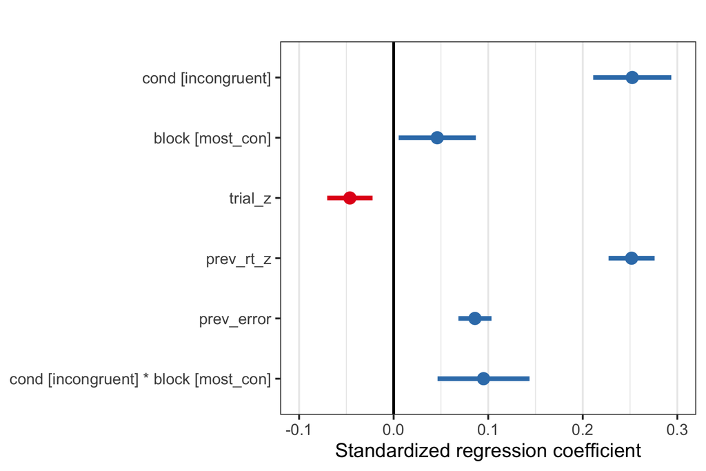

```r
plot(gg)
```

```r
ggsave(gg, filename="Flanker_RT_Params.pdf", width=9, height=9, useDingbats=FALSE)
```

## m18: Allow for prev_rt_z x prev_error interaction

Not a slam dunk, but a small interaction. Omit for simplicity.

```r
minfo[["m18"]] <- c(
  fixed="Congruency, Block, Trial, Congruency x Trial, Previous RT,\nPrevious Error, Previous RT x Previous Error",
  l2="Block within subject: Intercept, Trial, Run Trial, Previous RT\nSubject: Congruency, Previous Error")
```

```r
m18 <- lmer(rt_inv ~ cond*block + trial_z + prev_rt_z * prev_error +
              (1 + trial_z + prev_rt_z + cond + prev_error | id) +
              (1 + trial_z + run_trial_z + prev_rt_z | id:block),
          na.action = na.exclude, control=lmerControl(optCtrl=list(maxfun=2e4)), #bump up iterations
          data = flanker, REML=FALSE) # control=lmerControl(optimizer = "nlminbwrap"))
if (isSingular(m18)) { print(check_singularity(m18)) }
```

```r
flextb_vif(m18)
```

| Predictor | vif |
| --- | --- |
| cond | 1.67 |
| block | 1.59 |
| trial_z | 1.03 |
| prev_rt_z | 1.09 |
| prev_error | 1.21 |
| cond:block | 1.87 |
| prev_rt_z:prev_error | 1.13 |

```r
car::Anova(m18, type=3)
```

```
## Analysis of Deviance Table (Type III Wald chisquare tests)
##
## Response: rt_inv
##                         Chisq Df Pr(>Chisq)
## (Intercept)          12489.75  1    < 2e-16 ***
## cond                   143.60  1    < 2e-16 ***
## block                    4.65  1    0.03098 *
## trial_z                 11.83  1    0.00058 ***
## prev_rt_z              426.43  1    < 2e-16 ***
## prev_error              76.40  1    < 2e-16 ***
## cond:block              14.56  1    0.00014 ***
## prev_rt_z:prev_error     4.21  1    0.04029 *
## ---
## Signif. codes:  0 '***' 0.001 '**' 0.01 '*' 0.05 '.' 0.1 ' ' 1
```

```r
flextable(render_aictab(minfo=minfo, m1, m2, m3, m4, m5, m6, m7, m8, m9, m10, m11, m12, m13, m14, m15, m16, m17, m18)) %>%
  autofit()
```

| model | fixed | l2 | logLik | AIC | dAIC | df | weight |
| --- | --- | --- | --- | --- | --- | --- | --- |
| m1 | Congruency, Block | Subject: Intercept | -7343 | 14698 | 3016.91 | 6 | 0.00e+00 |
| m2 | Congruency, Block | Block within subject: Intercept | -7279 | 14571 | 2890.24 | 7 | 0.00e+00 |
| m3 | Congruency, Block, Trial | Block within subject: Intercept | -7242 | 14500 | 2818.95 | 8 | 0.00e+00 |
| m4 | Congruency, Block, Trial | Block within subject:Intercept Subject: Trial | -6991 | 14002 | 2320.81 | 10 | 0.00e+00 |
| m5 | Congruency, Block, Trial | Block within subject: Intercept, Trial | -6943 | 13910 | 2229.07 | 12 | 0.00e+00 |
| m6 | Congruency, Block, Congruency x Block, Trial, Block x Trial | Block within subject: Intercept, Trial | -6943 | 13912 | 2231.02 | 13 | 0.00e+00 |
| m7 | Congruency, Block, Congruency x Block, Trial, Run Trial | Block within subject: Intercept, Trial | -6930 | 13886 | 2204.97 | 13 | 0.00e+00 |
| m8 | Congruency, Block, Trial, Run Trial | Block within subject: Intercept, Trial Subject: Run Trial | -6876 | 13783 | 2102.20 | 16 | 0.00e+00 |
| m9 | Congruency, Block, Congruency x Block, Trial, Run Trial | Block within subject:Intercept, Trial, Run Trial | -6823 | 13683 | 2001.80 | 19 | 0.00e+00 |
| m10 | Congruency, Block, Congruency x Block, Trial, Run Trial, Previous RT | Block within subject: Intercept, Trial, Run Trial | -5977 | 11993 | 312.11 | 20 | 9.71e-69 |
| m11 | Congruency, Block, Congruency x Block, Trial, Run Trial, Previous RT, Run Trial x Previous RT | Block within subject: Intercept, Trial, Run Trial | -5969 | 11981 | 299.70 | 21 | 4.80e-66 |
| m12 | Congruency, Block, Congruency x Block, Trial, Previous RT | Block within subject: Intercept, Trial, Run Trial, Previous RT | -5915 | 11884 | 202.86 | 27 | 5.12e-45 |
| m13 | Congruency, Block, Congruency x Block, Trial, Previous RT | Block within subject: Intercept, Trial, Run Trial, Previous RT Subject: Congruency | -5899 | 11861 | 180.25 | 32 | 4.17e-40 |
| m14 | Congruency, Block, Congruency x Block, Trial, Previous RT | Block within subject: Intercept, Trial, Run Trial, Previous RT, Congruency | -5895 | 11865 | 183.75 | 37 | 7.23e-41 |
| m15 | Congruency, Block, Congruency x Block, Trial, Previous RT, Previous Error | Block within subject: Intercept, Trial, Run Trial, Previous RT Subject: Congruency | -5825 | 11715 | 34.16 | 33 | 2.21e-08 |
| m16 | Congruency, Block, Congruency x Block, Trial, Previous RT, Previous Error | Block within subject: Intercept, Trial, Run Trial, Previous RT Subject: Congruency, Previous Error | -5803 | 11684 | 2.86 | 39 | 1.38e-01 |
| m17 | Congruency, Block, Congruency x Block, Trial, Previous RT, Previous Error | Block within subject: Intercept, Trial, Run Trial, Previous RT Subject: Congruency, Previous Error | -5808 | 11683 | 1.40 | 33 | 2.86e-01 |
| m18 | Congruency, Block, Trial, Congruency x Trial, Previous RT, Previous Error, Previous RT x Previous Error | Block within subject: Intercept, Trial, Run Trial, Previous RT Subject: Congruency, Previous Error | -5807 | 11681 | 0.00 | 34 | 5.76e-01 |

## m19: try to simplify random effect structure further: Drop trial_z within block

Eliminate small variance components for the trial_z id:block piece

```r
minfo[["m19"]] <- c(
  fixed="Congruency, Block, Congruency x Block,\nTrial, Previous RT, Previous Error",
  l2="Block within subject:Intercept, Run Trial, Previous RT\nSubject: Congruency, Trial, Previous Error")
```

```r
m19 <- lmer(rt_inv ~ cond*block + trial_z + prev_rt_z + prev_error +
              (1 + trial_z + prev_rt_z + cond + prev_error | id) +
              (1 + run_trial_z + prev_rt_z | id:block),
          na.action = na.exclude, control=lmerControl(optCtrl=list(maxfun=2e4)), #bump up iterations
          data = flanker, REML=FALSE) # control=lmerControl(optimizer = "nlminbwrap"))
if (isSingular(m19)) { print(check_singularity(m19)) }
```

```r
flextb_vif(m19)
```

| Predictor | vif |
| --- | --- |
| cond | 1.66 |
| block | 1.60 |
| trial_z | 1.03 |
| prev_rt_z | 1.10 |
| prev_error | 1.11 |
| cond:block | 1.87 |

```r
#car::Anova(m19, type=3)

flextable(render_aictab(minfo=minfo, m1, m2, m3, m4, m5, m6, m7, m8, m9, m10, m11, m12,
                        m13, m14, m15, m16, m17, m18, m19)) %>% autofit()
```

| model | fixed | l2 | logLik | AIC | dAIC | df | weight |
| --- | --- | --- | --- | --- | --- | --- | --- |
| m1 | Congruency, Block | Subject: Intercept | -7343 | 14698 | 3016.91 | 6 | 0.00e+00 |
| m2 | Congruency, Block | Block within subject: Intercept | -7279 | 14571 | 2890.24 | 7 | 0.00e+00 |
| m3 | Congruency, Block, Trial | Block within subject: Intercept | -7242 | 14500 | 2818.95 | 8 | 0.00e+00 |
| m4 | Congruency, Block, Trial | Block within subject:Intercept Subject: Trial | -6991 | 14002 | 2320.81 | 10 | 0.00e+00 |
| m5 | Congruency, Block, Trial | Block within subject: Intercept, Trial | -6943 | 13910 | 2229.07 | 12 | 0.00e+00 |
| m6 | Congruency, Block, Congruency x Block, Trial, Block x Trial | Block within subject: Intercept, Trial | -6943 | 13912 | 2231.02 | 13 | 0.00e+00 |
| m7 | Congruency, Block, Congruency x Block, Trial, Run Trial | Block within subject: Intercept, Trial | -6930 | 13886 | 2204.97 | 13 | 0.00e+00 |
| m8 | Congruency, Block, Trial, Run Trial | Block within subject: Intercept, Trial Subject: Run Trial | -6876 | 13783 | 2102.20 | 16 | 0.00e+00 |
| m9 | Congruency, Block, Congruency x Block, Trial, Run Trial | Block within subject:Intercept, Trial, Run Trial | -6823 | 13683 | 2001.80 | 19 | 0.00e+00 |
| m10 | Congruency, Block, Congruency x Block, Trial, Run Trial, Previous RT | Block within subject: Intercept, Trial, Run Trial | -5977 | 11993 | 312.11 | 20 | 9.71e-69 |
| m11 | Congruency, Block, Congruency x Block, Trial, Run Trial, Previous RT, Run Trial x Previous RT | Block within subject: Intercept, Trial, Run Trial | -5969 | 11981 | 299.70 | 21 | 4.80e-66 |
| m12 | Congruency, Block, Congruency x Block, Trial, Previous RT | Block within subject: Intercept, Trial, Run Trial, Previous RT | -5915 | 11884 | 202.86 | 27 | 5.12e-45 |
| m13 | Congruency, Block, Congruency x Block, Trial, Previous RT | Block within subject: Intercept, Trial, Run Trial, Previous RT Subject: Congruency | -5899 | 11861 | 180.25 | 32 | 4.17e-40 |
| m14 | Congruency, Block, Congruency x Block, Trial, Previous RT | Block within subject: Intercept, Trial, Run Trial, Previous RT, Congruency | -5895 | 11865 | 183.75 | 37 | 7.23e-41 |
| m15 | Congruency, Block, Congruency x Block, Trial, Previous RT, Previous Error | Block within subject: Intercept, Trial, Run Trial, Previous RT Subject: Congruency | -5825 | 11715 | 34.16 | 33 | 2.21e-08 |
| m16 | Congruency, Block, Congruency x Block, Trial, Previous RT, Previous Error | Block within subject: Intercept, Trial, Run Trial, Previous RT Subject: Congruency, Previous Error | -5803 | 11684 | 2.86 | 39 | 1.38e-01 |
| m17 | Congruency, Block, Congruency x Block, Trial, Previous RT, Previous Error | Block within subject: Intercept, Trial, Run Trial, Previous RT Subject: Congruency, Previous Error | -5808 | 11683 | 1.40 | 33 | 2.86e-01 |
| m18 | Congruency, Block, Trial, Congruency x Trial, Previous RT, Previous Error, Previous RT x Previous Error | Block within subject: Intercept, Trial, Run Trial, Previous RT Subject: Congruency, Previous Error | -5807 | 11681 | 0.00 | 34 | 5.76e-01 |
| m19 | Congruency, Block, Congruency x Block, Trial, Previous RT, Previous Error | Block within subject:Intercept, Run Trial, Previous RT Subject: Congruency, Trial, Previous Error | -5821 | 11701 | 19.27 | 29 | 3.76e-05 |

## m20: drop run_trial_z random effect

```r
minfo[["m20"]] <- c(
  fixed="Congruency, Block, Congruency x Block,\nTrial, Previous RT, Previous Error",
  l2="Block within subject: Intercept, Trial, Previous RT\nSubject: Congruency, Previous Error")
```

```r
m20 <- lmer(rt_inv ~ cond*block + trial_z + prev_rt_z + prev_error +
              (1 + trial_z + prev_rt_z + cond + prev_error | id) +
              (1 + trial_z + prev_rt_z | id:block),
          na.action = na.exclude, control=lmerControl(optCtrl=list(maxfun=2e4)), #bump up iterations
          data = flanker, REML=FALSE) # control=lmerControl(optimizer = "nlminbwrap"))
if (isSingular(m20)) { print(check_singularity(m20)) }
```

```r
flextb_vif(m20)
```

| Predictor | vif |
| --- | --- |
| cond | 1.67 |
| block | 1.61 |
| trial_z | 1.03 |
| prev_rt_z | 1.09 |
| prev_error | 1.12 |
| cond:block | 1.88 |

```r
#car::Anova(m20, type=3)

flextable(render_aictab(minfo=minfo, m1, m2, m3, m4, m5, m6, m7, m8, m9, m10, m11,
                        m12, m13, m14, m15, m16, m17, m18, m19, m20)) %>% autofit()
```

| model | fixed | l2 | logLik | AIC | dAIC | df | weight |
| --- | --- | --- | --- | --- | --- | --- | --- |
| m1 | Congruency, Block | Subject: Intercept | -7343 | 14698 | 3016.91 | 6 | 0.00e+00 |
| m2 | Congruency, Block | Block within subject: Intercept | -7279 | 14571 | 2890.24 | 7 | 0.00e+00 |
| m3 | Congruency, Block, Trial | Block within subject: Intercept | -7242 | 14500 | 2818.95 | 8 | 0.00e+00 |
| m4 | Congruency, Block, Trial | Block within subject:Intercept Subject: Trial | -6991 | 14002 | 2320.81 | 10 | 0.00e+00 |
| m5 | Congruency, Block, Trial | Block within subject: Intercept, Trial | -6943 | 13910 | 2229.07 | 12 | 0.00e+00 |
| m6 | Congruency, Block, Congruency x Block, Trial, Block x Trial | Block within subject: Intercept, Trial | -6943 | 13912 | 2231.02 | 13 | 0.00e+00 |
| m7 | Congruency, Block, Congruency x Block, Trial, Run Trial | Block within subject: Intercept, Trial | -6930 | 13886 | 2204.97 | 13 | 0.00e+00 |
| m8 | Congruency, Block, Trial, Run Trial | Block within subject: Intercept, Trial Subject: Run Trial | -6876 | 13783 | 2102.20 | 16 | 0.00e+00 |
| m9 | Congruency, Block, Congruency x Block, Trial, Run Trial | Block within subject:Intercept, Trial, Run Trial | -6823 | 13683 | 2001.80 | 19 | 0.00e+00 |
| m10 | Congruency, Block, Congruency x Block, Trial, Run Trial, Previous RT | Block within subject: Intercept, Trial, Run Trial | -5977 | 11993 | 312.11 | 20 | 9.71e-69 |
| m11 | Congruency, Block, Congruency x Block, Trial, Run Trial, Previous RT, Run Trial x Previous RT | Block within subject: Intercept, Trial, Run Trial | -5969 | 11981 | 299.70 | 21 | 4.80e-66 |
| m12 | Congruency, Block, Congruency x Block, Trial, Previous RT | Block within subject: Intercept, Trial, Run Trial, Previous RT | -5915 | 11884 | 202.86 | 27 | 5.12e-45 |
| m13 | Congruency, Block, Congruency x Block, Trial, Previous RT | Block within subject: Intercept, Trial, Run Trial, Previous RT Subject: Congruency | -5899 | 11861 | 180.25 | 32 | 4.17e-40 |
| m14 | Congruency, Block, Congruency x Block, Trial, Previous RT | Block within subject: Intercept, Trial, Run Trial, Previous RT, Congruency | -5895 | 11865 | 183.75 | 37 | 7.23e-41 |
| m15 | Congruency, Block, Congruency x Block, Trial, Previous RT, Previous Error | Block within subject: Intercept, Trial, Run Trial, Previous RT Subject: Congruency | -5825 | 11715 | 34.16 | 33 | 2.21e-08 |
| m16 | Congruency, Block, Congruency x Block, Trial, Previous RT, Previous Error | Block within subject: Intercept, Trial, Run Trial, Previous RT Subject: Congruency, Previous Error | -5803 | 11684 | 2.86 | 39 | 1.38e-01 |
| m17 | Congruency, Block, Congruency x Block, Trial, Previous RT, Previous Error | Block within subject: Intercept, Trial, Run Trial, Previous RT Subject: Congruency, Previous Error | -5808 | 11683 | 1.40 | 33 | 2.86e-01 |
| m18 | Congruency, Block, Trial, Congruency x Trial, Previous RT, Previous Error, Previous RT x Previous Error | Block within subject: Intercept, Trial, Run Trial, Previous RT Subject: Congruency, Previous Error | -5807 | 11681 | 0.00 | 34 | 5.76e-01 |
| m19 | Congruency, Block, Congruency x Block, Trial, Previous RT, Previous Error | Block within subject:Intercept, Run Trial, Previous RT Subject: Congruency, Trial, Previous Error | -5821 | 11701 | 19.27 | 29 | 3.76e-05 |
| m20 | Congruency, Block, Congruency x Block, Trial, Previous RT, Previous Error | Block within subject: Intercept, Trial, Previous RT Subject: Congruency, Previous Error | -5827 | 11712 | 30.89 | 29 | 1.13e-07 |

## m21: drop intercept at id/block

```r
minfo[["m21"]] <- c(
  fixed="Congruency, Block, Congruency x Block,\nTrial, Previous RT, Previous Error",
  l2="Block within subject:Previous RT, Previous Error\nSubject: Congruency")
```

```r
m21 <- lmer(rt_inv ~ cond*block + trial_z + prev_rt_z + prev_error +
              (1 + trial_z + prev_rt_z + cond + prev_error | id) +
              (0 + trial_z + prev_rt_z | id:block),
          na.action = na.exclude, control=lmerControl(optCtrl=list(maxfun=2e4)), #bump up iterations
          data = flanker, REML=FALSE) # control=lmerControl(optimizer = "nlminbwrap"))
```

```
## boundary (singular) fit: see ?isSingular
```

```r
flextb_vif(m21)
```

| Predictor | vif |
| --- | --- |
| cond | 1.69 |
| block | 2.01 |
| trial_z | 1.01 |
| prev_rt_z | 1.05 |
| prev_error | 1.08 |
| cond:block | 2.10 |

```r
#car::Anova(m21, type=3)

flextable(render_aictab(minfo=minfo, m1, m2, m3, m4, m5, m6, m7, m8, m9, m10, m11, m12,
                        m13, m14, m15, m16, m17, m18, m19, m20, m21)) %>% autofit()
```

| model | fixed | l2 | logLik | AIC | dAIC | df | weight |
| --- | --- | --- | --- | --- | --- | --- | --- |
| m1 | Congruency, Block | Subject: Intercept | -7343 | 14698 | 3016.91 | 6 | 0.00e+00 |
| m2 | Congruency, Block | Block within subject: Intercept | -7279 | 14571 | 2890.24 | 7 | 0.00e+00 |
| m3 | Congruency, Block, Trial | Block within subject: Intercept | -7242 | 14500 | 2818.95 | 8 | 0.00e+00 |
| m4 | Congruency, Block, Trial | Block within subject:Intercept Subject: Trial | -6991 | 14002 | 2320.81 | 10 | 0.00e+00 |
| m5 | Congruency, Block, Trial | Block within subject: Intercept, Trial | -6943 | 13910 | 2229.07 | 12 | 0.00e+00 |
| m6 | Congruency, Block, Congruency x Block, Trial, Block x Trial | Block within subject: Intercept, Trial | -6943 | 13912 | 2231.02 | 13 | 0.00e+00 |
| m7 | Congruency, Block, Congruency x Block, Trial, Run Trial | Block within subject: Intercept, Trial | -6930 | 13886 | 2204.97 | 13 | 0.00e+00 |
| m8 | Congruency, Block, Trial, Run Trial | Block within subject: Intercept, Trial Subject: Run Trial | -6876 | 13783 | 2102.20 | 16 | 0.00e+00 |
| m9 | Congruency, Block, Congruency x Block, Trial, Run Trial | Block within subject:Intercept, Trial, Run Trial | -6823 | 13683 | 2001.80 | 19 | 0.00e+00 |
| m10 | Congruency, Block, Congruency x Block, Trial, Run Trial, Previous RT | Block within subject: Intercept, Trial, Run Trial | -5977 | 11993 | 312.11 | 20 | 9.71e-69 |
| m11 | Congruency, Block, Congruency x Block, Trial, Run Trial, Previous RT, Run Trial x Previous RT | Block within subject: Intercept, Trial, Run Trial | -5969 | 11981 | 299.70 | 21 | 4.80e-66 |
| m12 | Congruency, Block, Congruency x Block, Trial, Previous RT | Block within subject: Intercept, Trial, Run Trial, Previous RT | -5915 | 11884 | 202.86 | 27 | 5.12e-45 |
| m13 | Congruency, Block, Congruency x Block, Trial, Previous RT | Block within subject: Intercept, Trial, Run Trial, Previous RT Subject: Congruency | -5899 | 11861 | 180.25 | 32 | 4.17e-40 |
| m14 | Congruency, Block, Congruency x Block, Trial, Previous RT | Block within subject: Intercept, Trial, Run Trial, Previous RT, Congruency | -5895 | 11865 | 183.75 | 37 | 7.23e-41 |
| m15 | Congruency, Block, Congruency x Block, Trial, Previous RT, Previous Error | Block within subject: Intercept, Trial, Run Trial, Previous RT Subject: Congruency | -5825 | 11715 | 34.16 | 33 | 2.21e-08 |
| m16 | Congruency, Block, Congruency x Block, Trial, Previous RT, Previous Error | Block within subject: Intercept, Trial, Run Trial, Previous RT Subject: Congruency, Previous Error | -5803 | 11684 | 2.86 | 39 | 1.38e-01 |
| m17 | Congruency, Block, Congruency x Block, Trial, Previous RT, Previous Error | Block within subject: Intercept, Trial, Run Trial, Previous RT Subject: Congruency, Previous Error | -5808 | 11683 | 1.40 | 33 | 2.86e-01 |
| m18 | Congruency, Block, Trial, Congruency x Trial, Previous RT, Previous Error, Previous RT x Previous Error | Block within subject: Intercept, Trial, Run Trial, Previous RT Subject: Congruency, Previous Error | -5807 | 11681 | 0.00 | 34 | 5.76e-01 |
| m19 | Congruency, Block, Congruency x Block, Trial, Previous RT, Previous Error | Block within subject:Intercept, Run Trial, Previous RT Subject: Congruency, Trial, Previous Error | -5821 | 11701 | 19.27 | 29 | 3.76e-05 |
| m20 | Congruency, Block, Congruency x Block, Trial, Previous RT, Previous Error | Block within subject: Intercept, Trial, Previous RT Subject: Congruency, Previous Error | -5827 | 11712 | 30.89 | 29 | 1.13e-07 |
| m21 | Congruency, Block, Congruency x Block, Trial, Previous RT, Previous Error | Block within subject:Previous RT, Previous Error Subject: Congruency | -5843 | 11738 | 56.67 | 26 | 2.84e-13 |

In short, dropping any of the id:block random effects (m19-m21) substantially worsens fit.

## final model table

m17 is the winner – keep 1-17 for supp

```r
flextable(render_aictab(minfo=minfo[1:17], m1, m2, m3, m4, m5, m6, m7, m8, m9, m10, m11, m12,
                        m13, m14, m15, m16, m17)) %>% autofit()
```

| model | fixed | l2 | logLik | AIC | dAIC | df | weight |
| --- | --- | --- | --- | --- | --- | --- | --- |
| m1 | Congruency, Block | Subject: Intercept | -7343 | 14698 | 3015.51 | 6 | 0.00e+00 |
| m2 | Congruency, Block | Block within subject: Intercept | -7279 | 14571 | 2888.84 | 7 | 0.00e+00 |
| m3 | Congruency, Block, Trial | Block within subject: Intercept | -7242 | 14500 | 2817.55 | 8 | 0.00e+00 |
| m4 | Congruency, Block, Trial | Block within subject:Intercept Subject: Trial | -6991 | 14002 | 2319.41 | 10 | 0.00e+00 |
| m5 | Congruency, Block, Trial | Block within subject: Intercept, Trial | -6943 | 13910 | 2227.67 | 12 | 0.00e+00 |
| m6 | Congruency, Block, Congruency x Block, Trial, Block x Trial | Block within subject: Intercept, Trial | -6943 | 13912 | 2229.62 | 13 | 0.00e+00 |
| m7 | Congruency, Block, Congruency x Block, Trial, Run Trial | Block within subject: Intercept, Trial | -6930 | 13886 | 2203.57 | 13 | 0.00e+00 |
| m8 | Congruency, Block, Trial, Run Trial | Block within subject: Intercept, Trial Subject: Run Trial | -6876 | 13783 | 2100.80 | 16 | 0.00e+00 |
| m9 | Congruency, Block, Congruency x Block, Trial, Run Trial | Block within subject:Intercept, Trial, Run Trial | -6823 | 13683 | 2000.40 | 19 | 0.00e+00 |
| m10 | Congruency, Block, Congruency x Block, Trial, Run Trial, Previous RT | Block within subject: Intercept, Trial, Run Trial | -5977 | 11993 | 310.71 | 20 | 2.29e-68 |
| m11 | Congruency, Block, Congruency x Block, Trial, Run Trial, Previous RT, Run Trial x Previous RT | Block within subject: Intercept, Trial, Run Trial | -5969 | 11981 | 298.30 | 21 | 1.13e-65 |
| m12 | Congruency, Block, Congruency x Block, Trial, Previous RT | Block within subject: Intercept, Trial, Run Trial, Previous RT | -5915 | 11884 | 201.46 | 27 | 1.21e-44 |
| m13 | Congruency, Block, Congruency x Block, Trial, Previous RT | Block within subject: Intercept, Trial, Run Trial, Previous RT Subject: Congruency | -5899 | 11861 | 178.85 | 32 | 9.83e-40 |
| m14 | Congruency, Block, Congruency x Block, Trial, Previous RT | Block within subject: Intercept, Trial, Run Trial, Previous RT, Congruency | -5895 | 11865 | 182.35 | 37 | 1.70e-40 |
| m15 | Congruency, Block, Congruency x Block, Trial, Previous RT, Previous Error | Block within subject: Intercept, Trial, Run Trial, Previous RT Subject: Congruency | -5825 | 11715 | 32.76 | 33 | 5.20e-08 |
| m16 | Congruency, Block, Congruency x Block, Trial, Previous RT, Previous Error | Block within subject: Intercept, Trial, Run Trial, Previous RT Subject: Congruency, Previous Error | -5803 | 11684 | 1.46 | 39 | 3.25e-01 |
| m17 | Congruency, Block, Congruency x Block, Trial, Previous RT, Previous Error | Block within subject: Intercept, Trial, Run Trial, Previous RT Subject: Congruency, Previous Error | -5808 | 11683 | 0.00 | 33 | 6.75e-01 |

```r
summary(m17)
```

```
## Linear mixed model fit by maximum likelihood . t-tests use Satterthwaite's method ['lmerModLmerTest']
## Formula: rt_inv ~ cond * block + trial_z + prev_rt_z + prev_error + (1 +
##     trial_z + prev_rt_z + cond + prev_error | id) + (1 + trial_z +      run_trial_z + prev_rt_z | id:block)
##    Data: flanker
## Control: lmerControl(optCtrl = list(maxfun = 20000))
##
##      AIC      BIC   logLik deviance df.resid
##    11683    11936    -5808    11617    15744
##
## Scaled residuals:
##    Min     1Q Median     3Q    Max
## -4.709 -0.592  0.005  0.593  4.646
##
## Random effects:
##  Groups   Name            Variance Std.Dev. Corr
##  id:block (Intercept)     0.001488 0.0386
##           trial_z         0.002911 0.0540   -0.05
##           run_trial_z     0.001344 0.0367   -0.08 -0.34
##           prev_rt_z       0.000877 0.0296   -0.44  0.23  0.49
##  id       (Intercept)     0.056884 0.2385
##           trial_z         0.001785 0.0423   -0.05
##           prev_rt_z       0.001688 0.0411   -0.04 -0.11
##           condincongruent 0.003409 0.0584   -0.36 -0.33 -0.13
##           prev_error      0.023561 0.1535    0.16 -0.05  0.54 -0.39
##  Residual                 0.113909 0.3375
## Number of obs: 15777, groups:  id:block, 214; id, 107
##
## Fixed effects:
##                                  Estimate  Std. Error          df t value Pr(>|t|)
## (Intercept)                      -2.71651     0.02444   119.04772 -111.17  < 2e-16 ***
## condincongruent                   0.12045     0.01006   260.54362   11.98  < 2e-16 ***
## blockmost_con                     0.02119     0.00995   253.48965    2.13  0.03412 *
## trial_z                          -0.02207     0.00640    91.17503   -3.45  0.00085 ***
## prev_rt_z                         0.12047     0.00591   117.18438   20.40  < 2e-16 ***
## prev_error                        0.23397     0.02404    78.80894    9.73  3.7e-15 ***
## condincongruent:blockmost_con     0.04545     0.01184 15114.19541    3.84  0.00012 ***
## ---
## Signif. codes:  0 '***' 0.001 '**' 0.01 '*' 0.05 '.' 0.1 ' ' 1
##
## Correlation of Fixed Effects:
##             (Intr) cndncn blckm_ tril_z prv_r_ prv_rr
## condncngrnt -0.388
## blockmst_cn -0.259  0.478
## trial_z     -0.037 -0.119  0.002
## prev_rt_z   -0.026 -0.052 -0.002  0.053
## prev_error   0.076 -0.125  0.005 -0.018  0.284
## cndncngrn:_  0.166 -0.581 -0.583 -0.001  0.001 -0.006
## convergence code: 0
## Model failed to converge with max|grad| = 0.00367693 (tol = 0.002, component 1)
```

```r
#checking diagnostics: does the lower bound on the random effect encompass zero (singularity)
#https://rstudio-pubs-static.s3.amazonaws.com/33653_57fc7b8e5d484c909b615d8633c01d51.html
tt <- getME(m1_sc,"theta")
ll <- getME(m1_sc,"lower")
min(tt[ll==0])
```